# RE: Stepwise Forward Regression

# Setup

Let us load the {tidyverse} package for the whole session.

```r
library(tidyverse)
```

At first, we need to read the csv into R

```r
half_hourly_fluxes <- readr::read_csv(here::here(
  "data", "df_for_stepwise_regression.csv"))
half_hourly_fluxes |> head()
```

```
## # A tibble: 6 × 17
##   siteid TIMESTAMP    TA_F SW_IN_F LW_IN_F VPD_F  PA_F   P_F  WS_F TA_F_MDS
##   <chr>  <date>      <dbl>   <dbl>   <dbl> <dbl> <dbl> <dbl> <dbl>    <dbl>
## 1 CH-Dav 1997-01-01 -4.57     77.4    223. 0.565  82.6   0.4 0.559   -4.57
## 2 CH-Dav 1997-01-02 -3.34     45.6    235. 0.978  82.9   0   1.11    -3.34
## 3 CH-Dav 1997-01-03  0.278    74.1    239. 2.24   82.4   0   2.03     0.278
## 4 CH-Dav 1997-01-04 -1.88     58.1    250. 1.38   81.7   1.8 1.92    -1.88
## 5 CH-Dav 1997-01-05 -4.96     80.8    248. 1.16   82.3   0   0.407   -4.96
## 6 CH-Dav 1997-01-06 -4.48     59.6    237. 0.838  82.7   0   0.466   -4.48
## # ℹ 7 more variables: SW_IN_F_MDS <dbl>, LW_IN_F_MDS <dbl>, VPD_F_MDS <dbl>,
## #   CO2_F_MDS <dbl>, PPFD_IN <dbl>, GPP_NT_VUT_REF <dbl>, USTAR <dbl>
```

Then we need to get the names of the predictors. All variables besides `siteid`, `TIMESTAMP` and `GPP_NT_VUT_REF` (which is the target) are predictors.

```r
predictors <- half_hourly_fluxes |> names()
target <- "GPP_NT_VUT_REF"
# Remove those variable names
predictors <- predictors |> setdiff(c("siteid", "TIMESTAMP", target))
predictors
```

```
##  [1] "TA_F"        "SW_IN_F"     "LW_IN_F"     "VPD_F"       "PA_F"
##  [6] "P_F"         "WS_F"        "TA_F_MDS"    "SW_IN_F_MDS" "LW_IN_F_MDS"
## [11] "VPD_F_MDS"   "CO2_F_MDS"   "PPFD_IN"     "USTAR"
```

# Evaluation of all bivariate models

Now we start with `p = 1`:

```r
# Set up a tibble that contains the results (metrics) for the different models
metrics <- tibble(predictor = character(), R2 = numeric(), AIC = numeric())

for (pred in predictors) {
  # Create formula dynamically with reformulate(...)
  linmod <- lm(reformulate(pred, target), data = half_hourly_fluxes)
  cat(pred, "\n")
  metrics <- metrics |> add_row(predictor = pred, R2 = summary(linmod)$adj.r.squared, AIC = extractAIC(linmod)[2])
}
```

```
## TA_F
## SW_IN_F
## LW_IN_F
## VPD_F
## PA_F
## P_F
## WS_F
## TA_F_MDS
## SW_IN_F_MDS
## LW_IN_F_MDS
## VPD_F_MDS
## CO2_F_MDS
## PPFD_IN
## USTAR
```

```r
metrics
```

```
## # A tibble: 14 × 3
##    predictor           R2    AIC
##    <chr>            <dbl>  <dbl>
##  1 TA_F         0.387     37619.
##  2 SW_IN_F      0.431     36102.
##  3 LW_IN_F      0.168     43920.
##  4 VPD_F        0.191     43337.
##  5 PA_F         0.000192  47692.
##  6 P_F          0.00204   47654.
##  7 WS_F         0.00820   47526.
##  8 TA_F_MDS     0.387     37559.
##  9 SW_IN_F_MDS  0.430     36066.
## 10 LW_IN_F_MDS  0.121     25131.
## 11 VPD_F_MDS    0.181     42568.
## 12 CO2_F_MDS    0.0295    47079.
## 13 PPFD_IN      0.452     29690.
## 14 USTAR       -0.0000199 45049.
```

```r
# Get optimal metrics (highest R squared value)
optimal <- metrics |>
  slice_max(R2) |> # Extract rows with max value of R2
  slice(1) # Make sure only one single row taken (although here we only have single max.)
(optimal_pred <- optimal$predictor)
```

```
## [1] "PPFD_IN"
```

```r
best_mod <- lm(reformulate(optimal_pred, target),
               data = half_hourly_fluxes)

summary(best_mod)
```

```
##
## Call:
## lm(formula = reformulate(optimal_pred, target), data = half_hourly_fluxes)
##
## Residuals:
##     Min      1Q  Median      3Q     Max
## -8.0475 -1.3255 -0.3758  1.2780 12.3295
##
## Coefficients:
##             Estimate Std. Error t value Pr(>|t|)
## (Intercept)  0.72533    0.03057   23.73   <2e-16 ***
## PPFD_IN      0.01062    0.00009  117.98   <2e-16 ***
## ---
## Signif. codes:  0 '***' 0.001 '**' 0.01 '*' 0.05 '.' 0.1 ' ' 1
##
## Residual standard error: 2.41 on 16872 degrees of freedom
##   (6137 Beobachtungen als fehlend gelöscht)
## Multiple R-squared:  0.4521, Adjusted R-squared:  0.452
## F-statistic: 1.392e+04 on 1 and 16872 DF,  p-value: < 2.2e-16
```

We see that `PPFD_IN` (incoming photosynthetic photon flux density) lead to the best performance. This is not surprising because our aim is to predict `GPP` (gross primary production). `PPFD_IN` is the number of incoming photons in the 400-700 nm spectral range (per square meter per second) that plants are able to use for photosyntesis (see [Wikipedia](https://en.wikipedia.org/wiki/Photosynthetically_active_radiation)).

We also see that the AIC is very big, and we could probably improve the model by increasing `p`, so by choosing more than just one single predictor.

Let us visualize it.

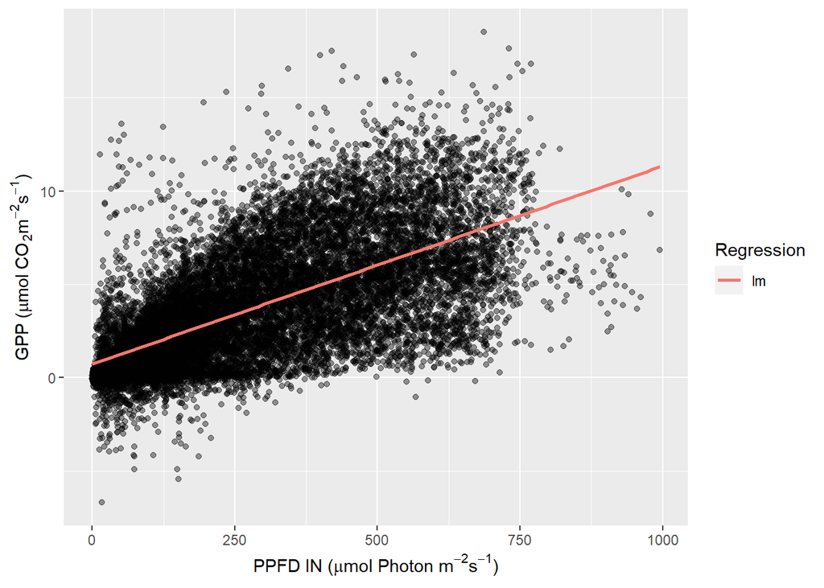

```r
half_hourly_fluxes |>  ggplot(aes(x = PPFD_IN, y = GPP_NT_VUT_REF)) +
  geom_point(alpha = 0.4, na.rm = TRUE) +
  geom_smooth(formula = y ~ x, method = "lm", aes(color = "lm"),
              se = FALSE, na.rm = TRUE) +
  labs(x = expression(paste("PPFD IN (", mu, "mol Photon m"^-2, "s"^-1, ")")),
       y = expression(paste("GPP (", mu, "mol CO"[2], "m"^-2, "s"^-1,")")),
       color = "Regression")
```

**Comment** The line matches the data to the most extent, but as we have so much variability in `GPP` for any value of `PPFD` between 0 and 750, it is not possible to accurately predict the `GPP` using only `PPFD`. For values of `PPFD` higher than 800, this model predicts a too high value of `GPP`. We have $R^2 \approx 0.45$ and $\text{AIC} \approx 29700$ which can surely be improved by adding more predictors.

# Complete stepwise forward regression

Now let us implement the complete stepwise forward regression algorithm. We can basically copy-paste the code from above and use it for our inner loop. Only slight modifications are necessary to make sure that we only check predictors only if they have not been used so far.

```r
# Initialize AIC metrics to infinity, so that at least one predictor will be chosen.
previous_AIC <- Inf
# Stores the predictors that will be used surely in the final model
selected_predictors <- c()
# Stores the remaining predictors (unsure whether they will be used in final model)
remaining_predictors <- predictors
optimal_metrics <- tibble(predictor = character(), R2 = numeric(), AIC = numeric())
for (p in 1:length(predictors)) {
  metrics <- tibble(predictor = character(), R2 = numeric(), AIC = numeric())
  for (pred in remaining_predictors) {
  linmod <- lm(
    reformulate(append(selected_predictors, pred), target),
    data = half_hourly_fluxes)
  metrics <- metrics |> add_row(predictor = pred,
                                R2 = summary(linmod)$adj.r.squared,
                                AIC = extractAIC(linmod)[2])
  }
  # Find the index (row number) where R2 was the best (highest)
  index_optimal <- which.max(pull(metrics, R2))
  optimal_pred <- remaining_predictors[index_optimal]
  optimal_pred_metrics <- metrics[index_optimal, ]
  cat("previous:", previous_AIC, ", now:", optimal_pred_metrics$AIC, "Did not improve\n")
  # If AIC does not improve, we don't add any predictors anymore and stop the algorithm.
  if (optimal_pred_metrics$AIC >= previous_AIC) {
    break
  }
  previous_AIC <- optimal_pred_metrics$AIC
  optimal_metrics <- optimal_metrics |> add_row(optimal_pred_metrics)
  # Add the optimal predictor
  selected_predictors <- append(selected_predictors, optimal_pred)
  # Remove the optimal predictor found in this step from the available predictors
  remaining_predictors <- remaining_predictors[remaining_predictors != optimal_pred]
}
```

```
## previous: Inf , now: 29689.54 Did not improve
## previous: 29689.54 , now: 27096.52 Did not improve
## previous: 27096.52 , now: 25420.8 Did not improve
## previous: 25420.8 , now: 24879.25 Did not improve
## previous: 24879.25 , now: 24728.65 Did not improve
## previous: 24728.65 , now: 24618.55 Did not improve
## previous: 24618.55 , now: 24542.84 Did not improve
## previous: 24542.84 , now: 24473.1 Did not improve
## previous: 24473.1 , now: 24469.29 Did not improve
## previous: 24469.29 , now: 24470.68 Did not improve
```

```r
(best_predictors <- selected_predictors)
```

```
## [1] "PPFD_IN"   "LW_IN_F"   "VPD_F"     "TA_F_MDS"  "SW_IN_F"   "P_F"
## [7] "WS_F"      "CO2_F_MDS" "PA_F"
```

```r
best_model <- lm(reformulate(best_predictors, target),
                 data = half_hourly_fluxes)
best_model |> summary()
```

```
##
## Call:
## lm(formula = reformulate(best_predictors, target), data = half_hourly_fluxes)
##
## Residuals:
##     Min      1Q  Median      3Q     Max
## -7.7477 -1.2228 -0.1153  1.1085 12.3241
##
## Coefficients:
##               Estimate Std. Error t value Pr(>|t|)
## (Intercept) -1.5891656  0.4463032  -3.561 0.000371 ***
## PPFD_IN      0.0067222  0.0005163  13.021  < 2e-16 ***
## LW_IN_F      0.0152432  0.0006854  22.240  < 2e-16 ***
## VPD_F       -0.3885851  0.0077764 -49.970  < 2e-16 ***
## TA_F_MDS     0.1035322  0.0049296  21.002  < 2e-16 ***
## SW_IN_F      0.0127810  0.0010750  11.889  < 2e-16 ***
## P_F         -0.0233915  0.0026829  -8.719  < 2e-16 ***
## WS_F        -0.1374643  0.0138279  -9.941  < 2e-16 ***
## CO2_F_MDS   -0.0064341  0.0007675  -8.383  < 2e-16 ***
## PA_F         0.0077160  0.0032004   2.411 0.015922 *
## ---
## Signif. codes:  0 '***' 0.001 '**' 0.01 '*' 0.05 '.' 0.1 ' ' 1
##
## Residual standard error: 2.064 on 16864 degrees of freedom
##   (6137 Beobachtungen als fehlend gelöscht)
## Multiple R-squared:  0.5982, Adjusted R-squared:  0.598
## F-statistic:  2790 on 9 and 16864 DF,  p-value: < 2.2e-16
```

**Comment** Stepwise linear regression suggests that `PPFD_IN`, `LW_IN_F`, `VPD_F`, `TA_F_MDS`, `SW_IN_F`,`P_F`, `WS_F`, `CO2_F_MDS`, `PA_F` are the optimal predictors for `GPP`. Their p-values are very low (significant) which means that it is very unlikely that the true coefficient of the corresponding predictor is actually zero. Their standard errors are very small but we have to keep in mind that they *must be compared to the actual estimate*. We see that the estimates of `Intercept`, and the predictors added at a late stage are the most uncertain ones.

Let us also compare how the $R^2$ and $\text{AIC}$ changed with each added predictor. Let us visualize the $R^2$ after each step:

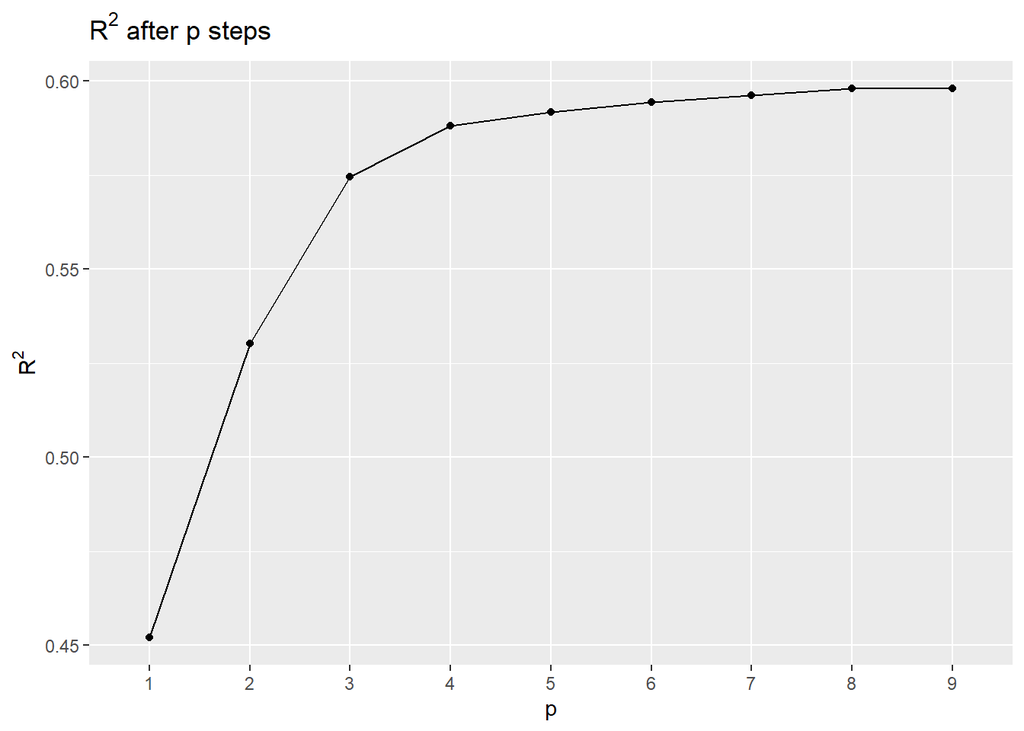

```r
predictor_number <- factor(1:nrow(optimal_metrics))
plot <- optimal_metrics |> ggplot(aes(x = predictor_number, y = R2, group = 1)) +
  geom_point() +
  geom_line() +
  labs(x = "p", y = expression(R^2),
       title = expression(paste(R^2, " after p steps"))
  )
plot
```

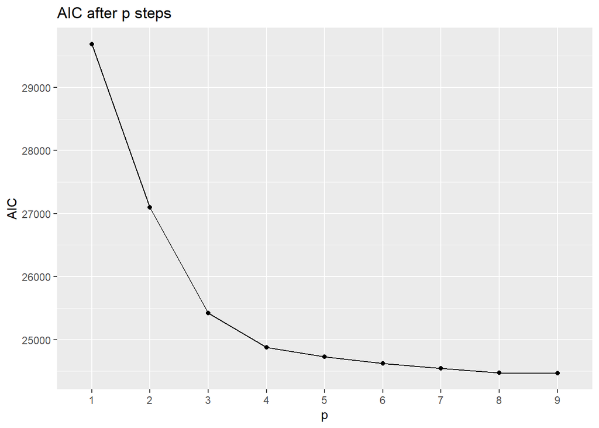

```r
plot <- optimal_metrics |> ggplot(aes(x = predictor_number, y = AIC, group = 1)) +
  geom_point() +
  geom_line() +
  labs(x = "p", y = "AIC",
       title = "AIC after p steps")
plot
```

They both develop similarly over time, just in opposite directions (because for $\text{AIC}$ lower means better and for $R^2$ higher means better). Until $p = 4$ there was a high increase (decrease) with every added predictor, then the increase (decrease) then it flattened. At $p = 9$, where the stepwise LR algorithm stopped, we have $R^2 \approx 0.60$ and $\text{AIC} \approx 24500$. Compared to the values at $p = 1$ ($R^2 \approx 0.45$ and $\text{AIC} \approx 29700$) this is quite an improvement.